# Ensemble Quantum Computing Laboratory

# Lab 1

## Experiment 1: Free Induction Decay (water) - 1H

### Pulse sequence:

In this experiment we need to apply a $\pi/2$ pulse, pulse program for such a pulse sequence is as follows:

pulse(1,a90H,p1,d90H)

### Parameters:

| Name | Value |
| --- | --- |
| Nucleus | 1H |
| 1H frequency(MHz) | 62.3733448 |
| Centre Frequency(ppm) | 4.74 |
| Pulse Length ($\mu\text{s}$) | 12.4 |
| Repitition time (ms) | 20000 |
| Number of points | 2048 |
| Dwell time ($\mu\text{s}$) | 500 |
| Receiver phase | 180 |

### Observations:

1. **The chemical shift**: observed in the frequency domain of the received signal. In the experiment we conducted, the chemical shift is 4.74ppm, which is approximatly 293.78Hz
2. **The form of the signal**: The FID signal for receiver on resonance is shown in Figure 1 and 2 below, the time domain signal displays the envelope of the decaying signal, the frequency domain signal shows the dominant frequency component in the received signal. The off resonance signal is shown in Figure 3 and Figure 4, being off resonance will introduce oscillation in the time domain signal and lower SNR in the frequency domain signal.

   Figure 1. Time domain signal from on-resonance receiver for FID of 1H in water

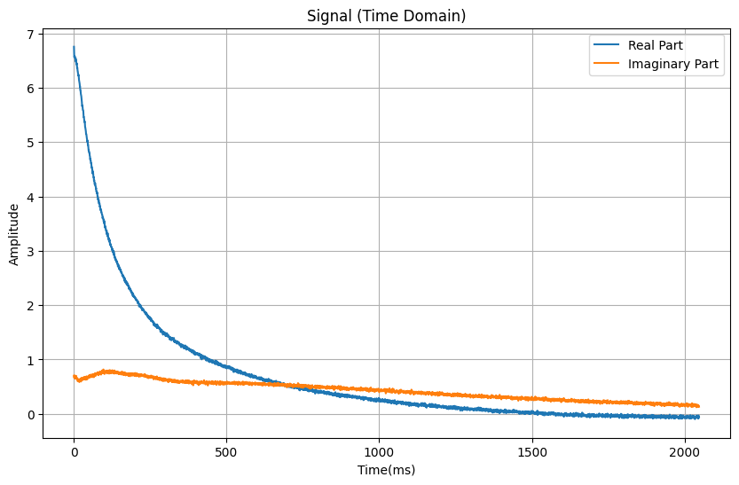

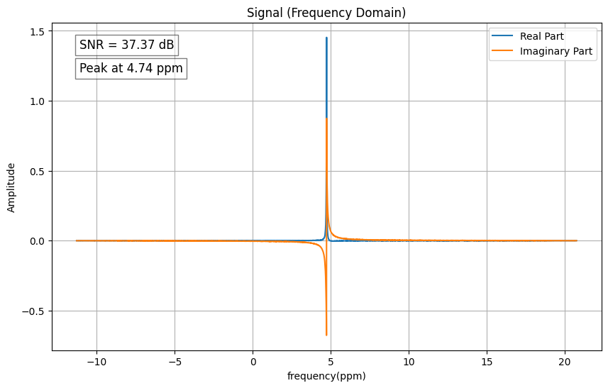

   Figure 3. Time domain signal from off-resonance receiver for FID of 1H in water

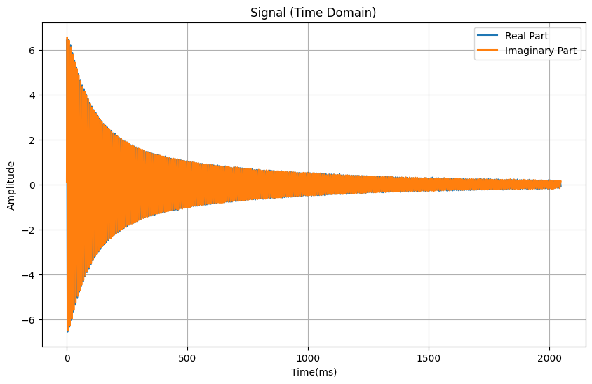

   Figure 4. Frequency domain signal from off-resonance receiver for FID of 1H in water

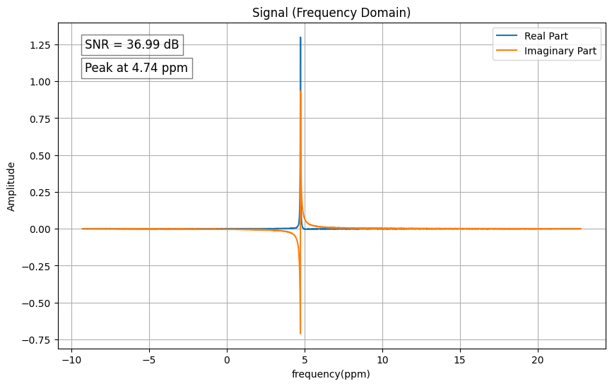

3. **Out-of-window pulse**: For signal outside of receiver windows, we investigated two scenario. First, when the signal is barely out of the receiver window, we implement receiver configuration as such:

| Name | Value |
| --- | --- |
| Nucleus | 1H |
| 1H frequency(MHz) | 62.3733448 |
| Pulse Length ($\mu\text{s}$) | 12.4 |
| Centre Frequency(ppm) | 18.74 |
| Number of points | 2048 |
| Dwell time ($\mu\text{s}$) | 500 |
| Receiver phase | 180 |

For this configuration, the window is 32ppm. The signal acquired is shown in Figure 5 and 6 below, the signal is intact and the SNR is slightly lowered.

The seconde implimentation we drive the signal far away from our acquisition window using configuration as follows:

| Name | Value |
| --- | --- |
| Nucleus | 1H |
| 1H frequency(MHz) | 62.3733448 |
| Pulse Length ($\mu\text{s}$) | 12.4 |
| Centre Frequency(ppm) | 48.74 |
| Number of points | 2048 |
| Dwell time ($\mu\text{s}$) | 500 |
| Receiver phase | 180 |

For this implimentation, the signal are shown in Figure 7 and 8, the signal is mainly noise in time domain and the peak in the frequency domain is not the signal we hope for and has low SNR

Figure 5. Time domain signal from receiver configuration that the acquisition window of such a receiver almost exclude the centre frequency of the desired signal

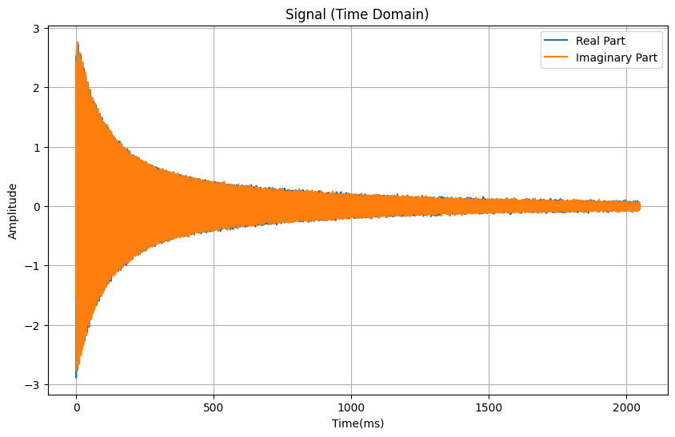

Figure 6. Frequency domain signal from receiver configuration that the acquisition window of such a receiver almost exclude the centre frequency of the desired signal

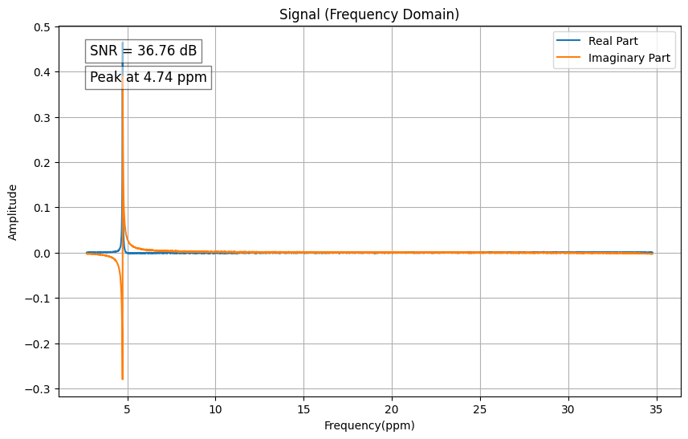

Figure 7. Time domain signal from receiver configuration that the acquisition window of such a receiver exclude the centre frequency of the desired signal

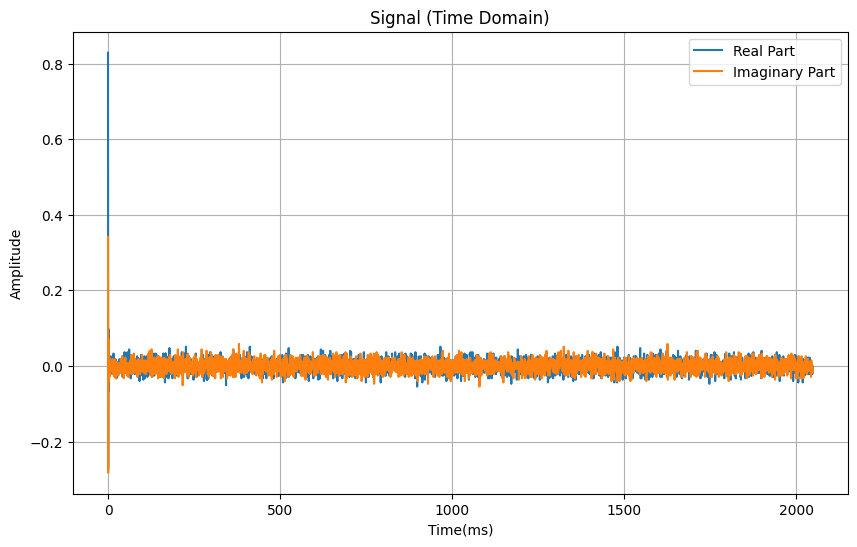

Figure 8. Frequency domain signal from receiver configuration that the acquisition window of such a receiver exclude the centre frequency of the desired signal

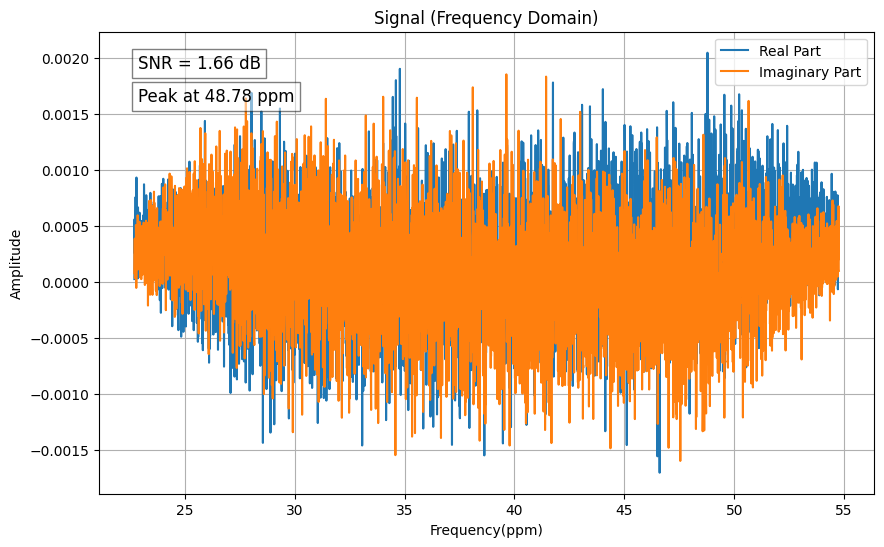

4. **Pulse length ~ signal relation**: The integral of observable signal in frequency domain present sinusoidal relation with the pulse length, the detail of which is presented in experiment 2. Under the parameter of experiment 1, a approximate pulse length of 180 degree rotation is 25 $\mu\text{s}$, which is in reasonably close to the expected value compared to 90-degree pulse.
5. **repetition time**: this means the duration of time between the start of two pulse sequences, e.g. a pulse sequence begins at t=0s, repetition time is set at 30000ms, the second pulse sequence will begin at t=30s.
6. **The $\text{T}_2^*$ time**: The $T_2^*$ for the signal collected in this experiment is 164.5ms, shown in Figure 9.

   Figure 9. Find the duration before the envelope decreased to $\frac{1}{e}$ of the max value

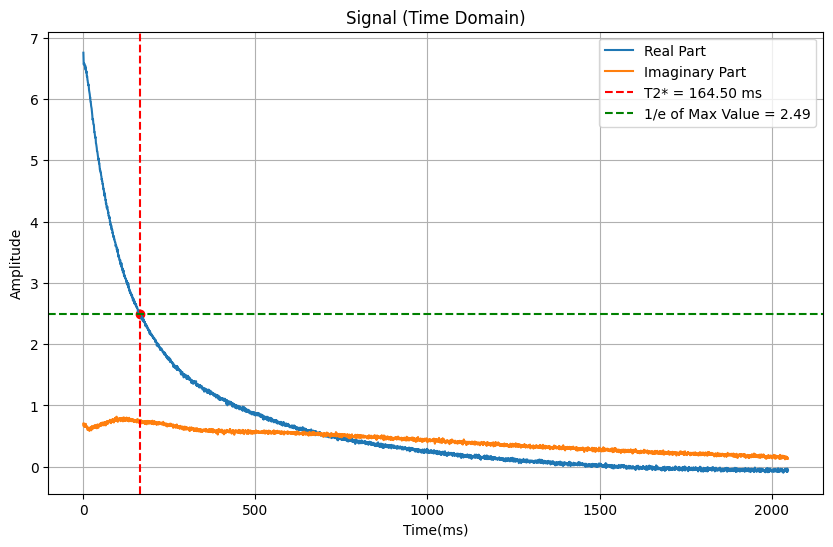

7. **The number of points and the dwell time**: For this experiment, we used 2048 number of points and 500 $\mu\text{s}$ dwell time. The time interval between successive digitized points in the FID. It is inversely related to the spectral width (SW), SW=1/dwell_time. The total number of data points sampled during the acquisition. The total acquisition time (AQ) is therefore AQ = N * dwell time. In the time domain, the initial amplitude of the FID (right after the RF pulse) is essentially independent of how frequently you sample it, provided you do sample fast enough to avoid digitization artifacts. In the frequency domain, the peak amplitude can appear to change if the software scales the Fourier transform differently for different N. However, with proper normalization, the true signal amplitude (or integrated peak area) does not fundamentally change just by changing dwell time or number of points (assuming the same total time and no aliasing). With a fixed AQ, Shorter dwell time, more points → larger spectral width but the same overall time-domain length → same resolution and similar SNR; Longer dwell time, fewer points → smaller spectral width but still the same AQ → same resolution, similar SNR.

In our case our peak resoltion is 1.1Hz, our window is 32ppm.

8. **Phase correction parameter**: for this experiment we used the phase correction parameter of 180 degree.

## Experiment 2: Proton pulse length calibration

### Intuition:

Apply a $\pi/2$ pulse to the spins, then turn on the receiver to see what happens.

Except if we think about it, we don't know the correct pules configuration for a $\pi/2$ pules. To find that out, we do the following:

Repeat the process many times with constant pules amplitude and various pules length. The pules length corresponding to the highest spectra integral is the correct pules.length for the $\pi/2$ pules

### Pulse sequence:

pulse(1,a90H,p1,d90H)

### Parameters:

| Name | Value |
| --- | --- |
| Nucleus | 1H |
| Centre Frequency(ppm) | 4.8 |
| 1H frequency(MHz) | 62.3733448 |
| Min. Pulse Length ($\mu\text{s}$) | 1 |
| Pulse step size | 1 |
| Nr. of length steps | 25 |
| Repitition time (ms) | 30000 |
| Number of points | 2048 |
| Dwell time ($\mu\text{s}$) | 500 |

### Observations:

1. The pulse length~amplitude~intensity relation is shown in Figure 1 below:

   Figure 1. The frequency domain signal for different pulse length

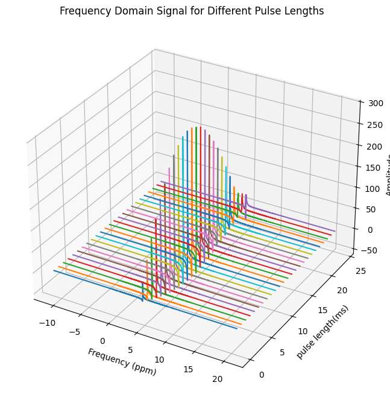

2. After acquiring all the frequency domain signal for different pulse length, we conducted integration on the peak and investigated the pulse length~integration relation more directly in Figure 2, the analysis conclude that the $\pi/2$ pulse from our experiment should be 10.74ms.

   Figure 2. The integrated signal vs pulse length plot

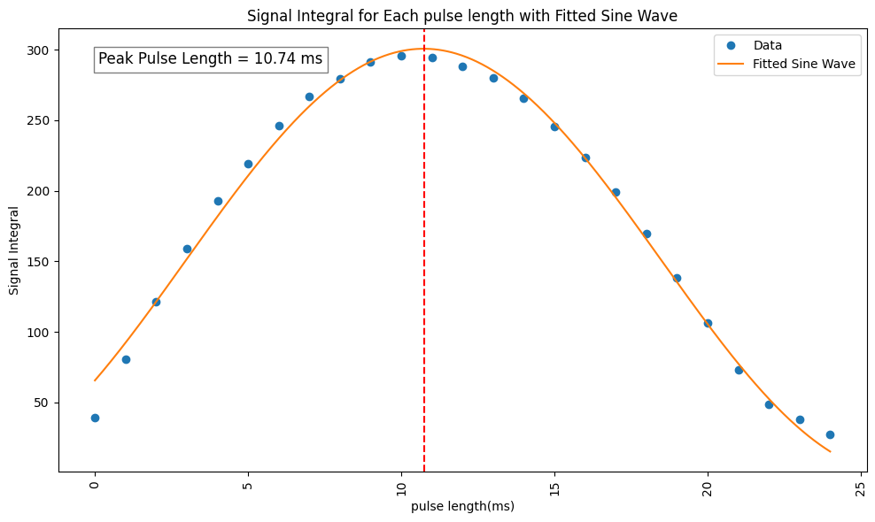

3. The result does not agree with the pulse length the SpinSolve system provide, combined with the experience we gathered in later experiments, we believe the error stem from the fact that we are not using long enough a repitition time for the spins to relax completely, resulting in the accumulation of the effect of adjacent pulses, which lead to shorter pulse length.

## Experiment 3: Inversion Recovery

### Concepts and Intuitions:

1. $T_1$ time: $T_1$ time is the time for the net magnetization return to $(1-\frac{1}{e})$ of it's equilibrium after being perturbed by RF pulses. This relaxation process occurs due to interactions between the nuclear spins and their surrounding molecular environment (the lattice), resulting in the transfer of energy from the spins to the lattice. As a result, $T_1$ reflects the efficiency of energy dissipation from the spin system to its surroundings.
2. The mathematical expression for $T_1$ is $I_t = I_0(1-e^{\frac{t}{T_1}})$

### Pulse sequence:

```
     pulse(1,a90H,p1,d180H)
     wait(w1)
     pulse(1,a90H,p1,d90H)
```

### Parameters:

| Name | Value |
| --- | --- |
| Nucleus | 1H |
| Centre Frequency(ppm) | 4.8 |
| 1H frequency(MHz) | 62.3733448 |
| Pulse Length ($\mu\text{s}$) | 12.4 |
| Min. delay (ms) | 5000 |
| Max. delay (ms) | 15000 |
| Number of steps | 5 |
| Repitition time (ms) | 30000 |
| Number of points | 2048 |
| Dwell time ($\mu\text{s}$) | 500 |

### Observations:

1. Using the mathematical expression mentioned above, the data we obtained fitted to $T_1$ time of 9.46s. The fitted curve and the integration of the signal for different delay time is shown in Figure 1 below

   Figure 1. The delay time~signal integration relation

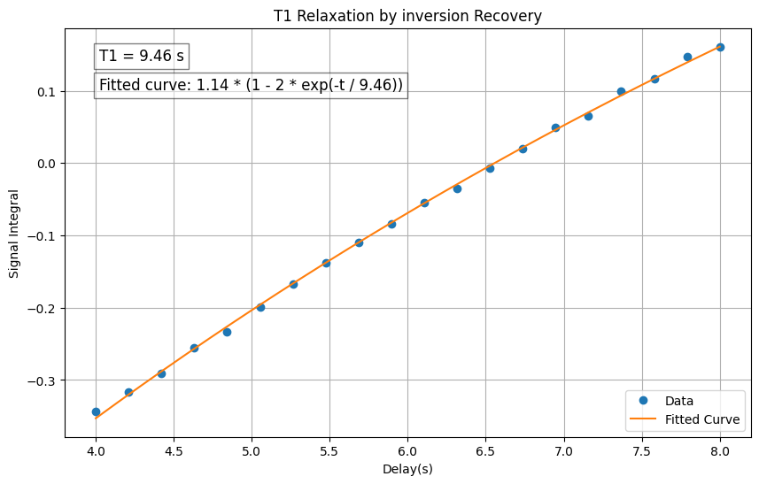

2. The repitition time is 30s for our sweep, the decition process behind this selection is as follows: we did a rough run with few data points but long repetition time sweep (shown in Figure 2) to get a rough idea of what the $T_1$ might be, then use $3T_1$ as a reasonable delay to conduct a more detailed sweep.

   Figure 2. The rough sweep

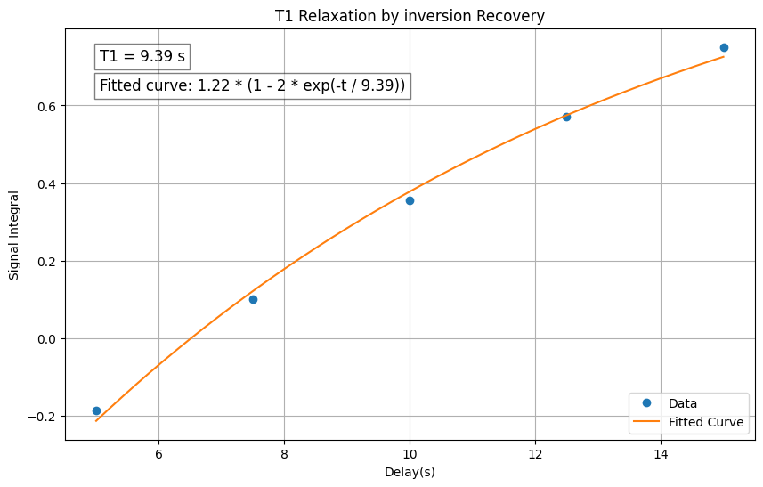

For $3T_1$, the intensity of the signal is expected to be reduced to $e^{-3}I_0$, which is less then 5%, therefore it is close enough for us to call it at equilibrium.

## Experiment 4: Saturation Recovery

### Concepts and Intuitions:

1. How saturation recovery works: Saturation recovery works in the following steps: 1). Wait for the spin to relax

   2). Rotate the spin to the transvers plane and wait for $T_2*$ time, where it is effected by the dephasing caused by slightly inhomogenouse magnetic field.

   Now the spin is spreaded on the transvers plane, let's say x-y plane

   3). Apply a $\pi/2$ pulse, let's assume along the x axis, any axis in the transvers plane is also good, to the spin and wait the same amount of time as last time. The inhomogenous magnetic field intorduce dephasing along x-y plane again. Now the spin is spreaded all over the place, the total magnetic moment is averaged out to be 0, shown in Figure 1 and 2 below.

   Figure 1. a messy bloch sphere

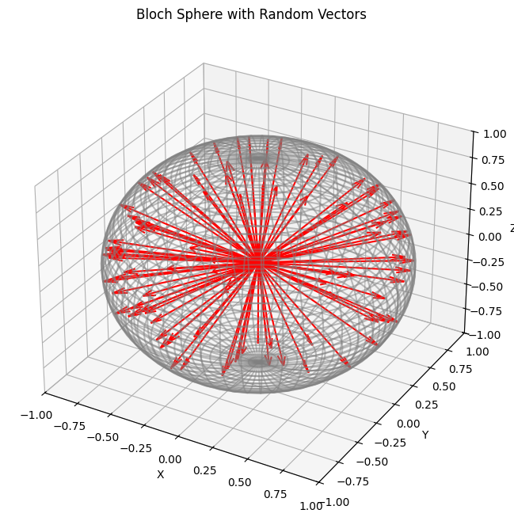

   Figure 2. the average of all those vectors

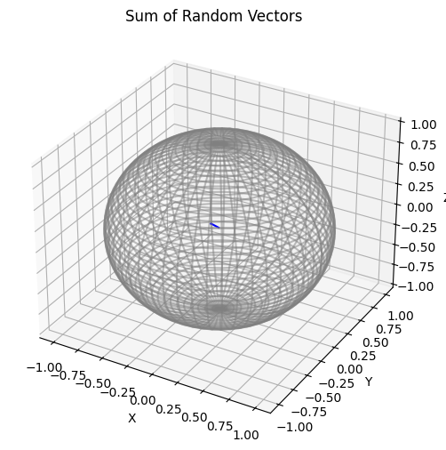

   If we apply a $\pi/2$ pulse right after these procedure, it is easy to see that the receiver will get nothing.

   4). Now that the vector is spreaded all over the place, we wait a bit so that the vectors can return to the equilibrium. If we wait a short period of time, this is what the vectors and there sum are going to look like:

   Figure 3. half-way towards the equilibrium

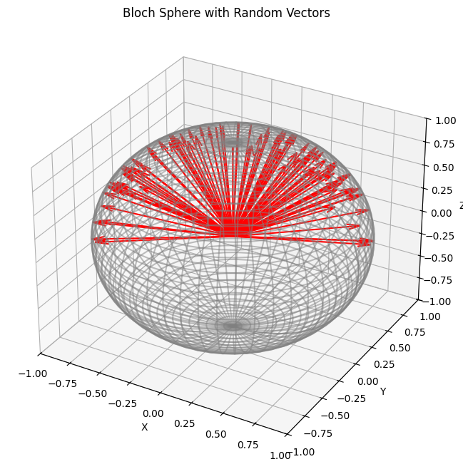

   Figure 4. their sum

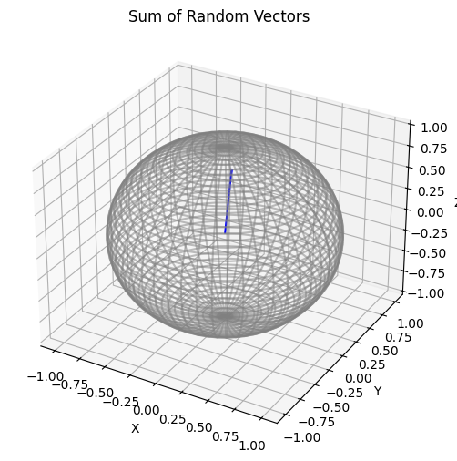

   So it is really easy to deduct what will happen if we apply a $\pi/2$ pulse at this point: we get a not so strong signal. If we wait longer, the signal will get stronger, until the spins are allowed to return to the equilibrium, at that point we will get the max signal.

   5). It is pretty clear now then, we do this experiment many times with different waiting duration, then fit it to the $T_1$ curve mentioned in experiment three, the $T_1$ is thereby obtained.

Please note that here in step 2 and 3 I used a simplified discription to saturate the bloch sphere, in practice we need to repeat step 3 more times so the saturation is good enough.

2. Why $T_2^*$ between each $\pi/2$ pulses when creating a saturation? To maximize the effect of the saturation in the transvers plane.

### Pulse sequence:

```
     pulse(1,a90H,p1,d90H)
     wait(dSat)
     pulse(1,a90H,p1,d90H)
     wait(dSat)
     pulse(1,a90H,p1,d90H)
     wait(dSat)
     pulse(1,a90H,p1,d90H)
     wait(dSat)
     pulse(1,a90H,p1,d90H)
     wait(dSat)
     pulse(1,a90H,p1,d90H)
     wait(dSat)
     pulse(1,a90H,p1,d90H)
     wait(dSat)
     pulse(1,a90H,p1,d90H)
     wait(w1)
     pulse(1,a90H,p1,d90H)
```

### Parameters:

| Name | Value |
| --- | --- |
| Nucleus | 1H |
| Centre Frequency(ppm) | 4.8 |
| 1H frequency(MHz) | 62.3733448 |
| Pulse Length ($\mu\text{s}$) | 12.4 |
| Saturation delay(ms) | 100 |
| Min delay(ms) | 1 |
| Max delay(ms) | 30000 |
| Number of steps | 20 |
| Repitition time (ms) | 30000 |
| Number of points | 4096 |
| Dwell time ($\mu\text{s}$) | 200 |

### Observations:

1. The $T_1$ we gathered by implementing Saturation Recovery is 8.96s, which agrees with the result of Experiment 3

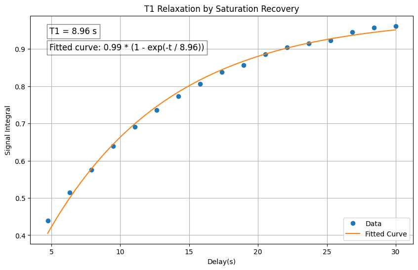

## Experiment 5: Hahn Echo

### Concepts and Intuitions:

1. $T_2$ and $T_2^*$: In a nut shell, $T_2$ is the Transverse Relaxation Time, it is determined by interaction between spins, $T_2^*$ is the Effective Transverse Relaxation Time, it is determined by static field inhomogeneities in the device.

### Pulse sequence

```
  pulse(1,a90H,p1,d90H)
  wait(wEcho)
  pulse(1,a90H,p1,d180H)
```

### Parameters:

| Name | Value |
| --- | --- |
| Nucleus | 1H |
| Centre Frequency(ppm) | 4.8 |
| 1H frequency(MHz) | 62.3733448 |
| Pulse Length ($\mu\text{s}$) | 12.4 |
| Echo time | 200 |
| Repitition time (ms) | 30000 |
| Number of points | 32768 |
| Dwell time ($\mu\text{s}$) | 10 |

### Observations:

1. The line width of the FID under spoild shim is 100.71Hz

   Figure 1. The Frequency domain signal of the FID after spoiling the shim

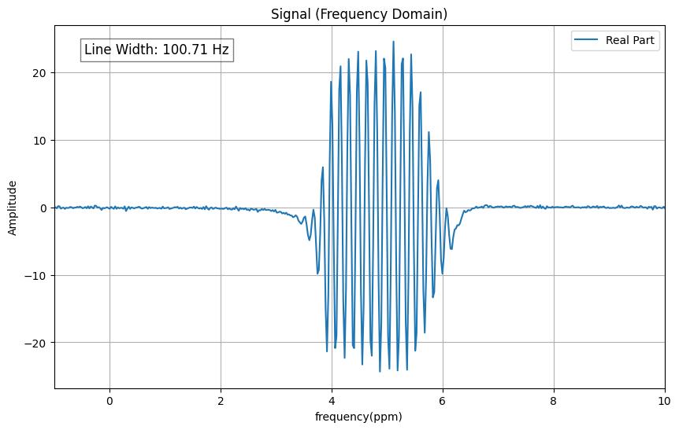

2. The $T_2^*$ of the FID in the spoiled shim is 4.2ms

   Figure 2. The Time domain signal of the FID after spiling the shim

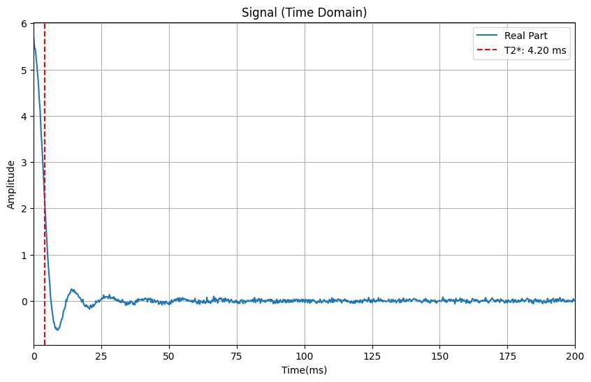

3. Here's the FID and echo we identified in our measurement

   Figure 3. The Time domain signal of the echo experiment

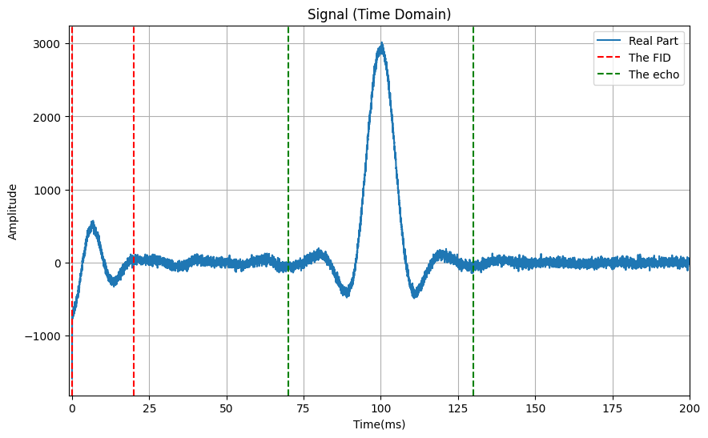

4. The relation between echotime adn echo amplitude: Unfortunately we do not have the time to conduct such experiment, so theoretical analysis is the best we can do on such topic. Given that in spin echo we mitigated the effect of static field inhomogeneities, the amplitude of echo is now governed by interaction between spins. Therefore we believe the amplitude of the echo will decrease exponantially, the speed of which is governed by $T_2$

## Experiment 6: Pulse amplitude calibration

### Pulse Program:

```
    pulse(1,a90H,p1,d90H)
```

### Parameters:

| Name | Value |
| --- | --- |
| Nucleus | 1H |
| Centre Frequency(ppm) | 4.8 |
| 1H frequency(MHz) | 62.3731834 |
| Pulse Length ($\mu\text{s}$) | 12.4 |
| Min. pulse Amplitude (dB) | 0 |
| Amplitude step size (dB) | -4 |
| Nr. of steps | 20 |
| Repitition time (ms) | 30000 |
| Number of points | 4096 |
| Dwell time ($\mu\text{s}$) | 500 |

### Observations:

1. With pulse length at 12.4 $\mu\text{s}$, we see 0dB pulse amplitude to the correct amplitude for $\pi/2$ pulse.

Figure 1. The amplitude~integral relation

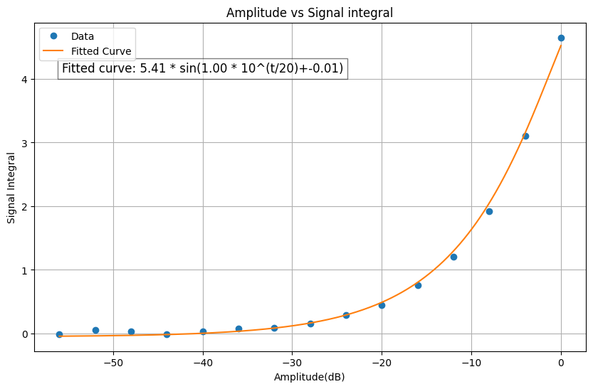

# Lab 2

## Experiment 1: 1H- Free Induction Decay in ${}^{13}CHCl_3$

### Pulse Program:

pulse(1,a90H,p1,d90H)

### Parameters:

| Name | Value |
| --- | --- |
| Nucleus | 1H |
| Centre Frequency(ppm) | 4.8 |
| 1H frequency(MHz) | 62.3734000 |
| Pulse Length ($\mu\text{s}$) | 12.4 |
| Repitition time (ms) | 10000 |
| Number of points | 8192 |
| Dwell time ($\mu\text{s}$) | 200 |

### Observations:

1. The Frequency domain signal is shown in Figure 1 below. We notice apart from the doublet introduced by 1H, there are two other small peaks. They are most likely the result of ${}^{12}CHCl_3$, impurities or minor solvent signals.

From the doublet, we observe the coupling strength J is 3.5ppm or 217Hz.

Figure 1. The Frequancy domain for FID for 1H in Choloroform

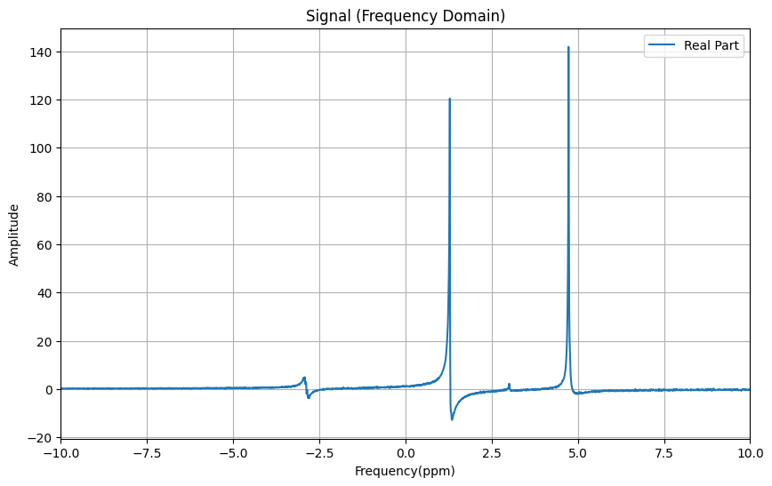

2. From the Time domain signal we observe the $T_2^*$ is 220ms
3. The other peaks are most likely ${}^{12}CHCl_3$ and impurities, for both smal peaks are singlets and ${}^{12}C$ does show one-bond coupling with the proton, also ${}^{13}C$, ${}^{35}Cl$ and ${}^{37}Cl$ are way out of the window here, therefore it is more likely to be ${}^{12}CHCl_3$ and impurity.
4. If we can be sure of one of the peak is indeed the result of the presence of ${}^{12}CHCl_3$, we can identify the ratio of ${}^{12}C$ and ${}^{13}C$ atoms.
5. The centre frequency we initially used is the center frequency of proton in water, it is close enough to get started. We then modify the center frequency to minimize the phase difference in the doublet.

## Experiment 2: T1 measurement (1H)

### Pulse Program:

```
    pulse(1,a90H,p1,d180H)
    wait(w1)
    pulse(1,a90H,p1,d90H)
```

### Parameters:

| Name | Value |
| --- | --- |
| Nucleus | 1H |
| Centre Frequency(ppm) | 4.8 |
| 1H frequency(MHz) | 62.3734000 |
| Pulse Length ($\mu\text{s}$) | 12.4 |
| Min. Delay | 1 |
| Max. Delay | 15000 |
| Number of steps | 20 |
| Repitition time (ms) | 30000 |
| Number of points | 8192 |
| Dwell time ($\mu\text{s}$) | 200 |

### Observations:

1. The delay~integral relation is shown in figure below, the $T_1$ time for 1H in choloroform is 3.57s, which is approximately one-third of the $T_1$ of 1H in water sample.

   Figure 1. the delay~integral relation and the fitted curve

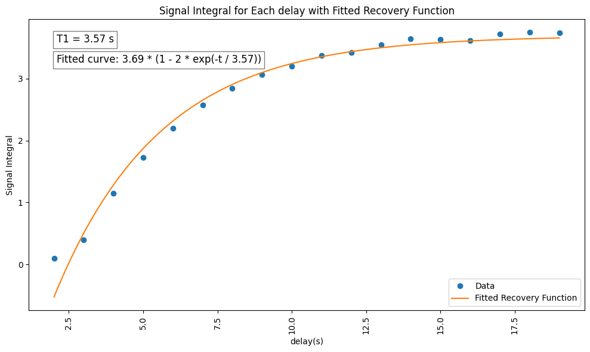

## Experiment 3: 13-C Free Induction Decay

### Pulse Program

```
    pulse(2,a90C,p1,d90C)
```

### Parameters:

| Name | Value |
| --- | --- |
| Nucleus | 13C |
| Centre Frequency(ppm) | 77 |
| 13C frequency(MHz) | 15.6854548 |
| Pulse Length ($\mu\text{s}$) | 75 |
| Pulse Amplitude (dB) | -5.9 |
| Repitition time (ms) | 15000 |
| Number of points | 4096 |
| Dwell time ($\mu\text{s}$) | 200 |

### Observation

   Figure 1. The Frequency domain signal for 13C in choloroform

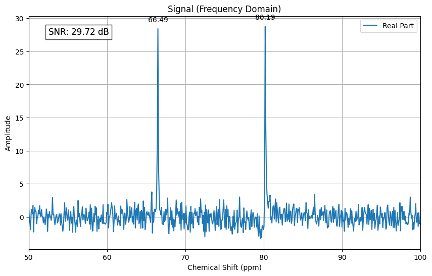

2. The J-coupling strength here is 215Hz. It is very close to the value calculated for 1H in experement 1.
3. The SNR of the signal for 13C is lower is because compare to 1H, it is precessing much slower than 1H, therefore creating weaker EM signal. The reason why it is precessing much slower is it has a much lower gyromagnetic ratio, approximately 10.7MHz/T, for comparison, that of 1H is approximately 42.6MHz/T.
4. How can we improve the SNR of 13C signal?
   1. With the experimental setup in hand, We can do multiple scans and average the signal. Assume white noise, the noise will average out while the signal is accumulated.
   2. We can transfer the polarization from proton to 13C using Nuclear Overhauser Effect.

## Experiment 4: 13-C Pulse length calibration

### Pulse Program:

```
    pulse(2,a90C,p1,d90C)
```

### Parameters:

| Name | Value |
| --- | --- |
| Nucleus | 13C |
| Centre Frequency(ppm) | 77 |
| 13C frequency(MHz) | 15.6853526 |
| Pulse Amplitude (dB) | -5.9 |
| Min pulse length | 1 |
| Pulse step size | 10 |
| Number of Length steps | 20 |
| Repitition time (ms) | 25000 |
| Number of points | 2048 |
| Dwell time ($\mu\text{s}$) | 200 |
| number of scans | 5 |

### Observations:

1. The Duration~Integral relation is as follows

   Figure 1. The Duration~Integral relation

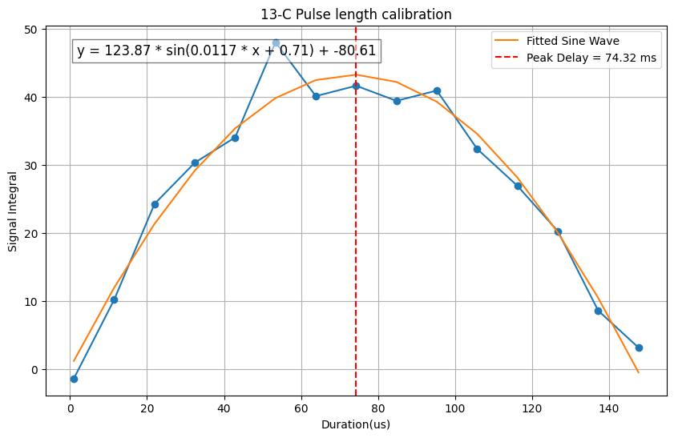

   The $\pi/2$ Pules length we found is 74.32 $\mu\text{s}$, which is very close to the value provided by the template. This pulse length is significantly longer than that of 1H.

## Experiment 5: Polarization transfer and decoupling

### Pulse Program

initpp(dir) # Reset internal parameter list

```
  cleardata(n1)
  waltzdecsetup(1,aDEC)

 # NOE transfer 1H->13C
  loop(l2,n3)
     WALTZ16(1, aNOE, d90, d180, d270, d360, p2, p3)
  endloop(l2)

 # 45 pulse on FID_NOE_13C_4
  delay(dAcq)
  pulse(2, a45C, p1, d45C)  # 45 degree 13C RF pulse
  delay(dPreAcq)

 # Acquire with 1H decoupling
  acquireon(n1)
    waltzdec(1, n2, aDEC, d90, d180, d270, d360, p2, p3)
  acquireoff("overwrite", n1)
```

lst = endpp(mode) # Return parameter list

### Parameters

| Name | Value |
| --- | --- |
| Nucleus | 13C |
| 13C Centre Frequency(ppm) | 77 |
| 13C frequency(MHz) | 15.6854548 |
| 13C Pulse Amplitude (dB) | -5.9 |
| 13C Pulse length | 35.15 |
| 1H frequency | 62.3734000 |
| Decouple amplitude | -20.9 |
| 1H 180 pulselength($\mu\text{s}$) | 281.2 |
| NOE delay time (ms) | 1000 |
| NOE power (dB) | -20.9 |
| pre-acqu. delay($\mu\text{s}$) | 42.801 |
| Pulse acqu. delay($\mu\text{s}$) | 20 |
| Repitition time (ms) | 3500 |
| Receiver gain | 37 |
| Receiver channel | 13C |
| Number of points | 4096 |
| Dwell time ($\mu\text{s}$) | 200 |
| number of scans | 5 |

### Observations:

1. How polarization transfer increases the SNR of ${}^{13}C$ signal by taking NOE into accout?

   To understand polarization transfer, let's look at how it is conducted: 1). the proton is excited, 2). proton and carbon are allowed to exchange magnetization with J-coupling, 3). a sequence of $\pi$ pulses are applied to allow transverse proton coherence transferred to a transverse carbon coherence.

   To understand NOE, we first look at this Solomon equation:

   $$ \frac{d(I_Z-I_Z^0)}{dt} = -R_I(I_Z - I_Z^0) - \sigma_{IS}(S_Z - S_Z^0)$$

   if S spin magnetization deviates from equilirium, the change caused by this in the I spin magnetization is proportional to such deviation. This change in I spin magnetization is effectively the change of the intensity in the corresponding spectrum.

   By combining the two, the effect of 13C FID is significantly better.

   Figure 1. The frequency domain signal with polarization transfer and decoupling

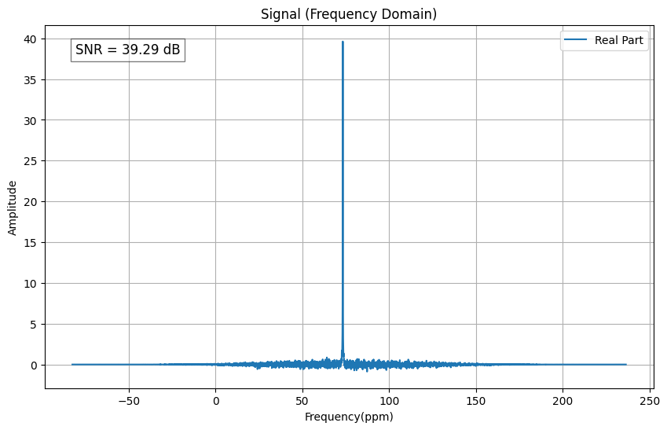

2. How does the decoupling work for 13C and 1H?

   protons are continually flipped faster than the timescale of the ${}^{13}C$ acquisition, From the ${}^{13}C$ viewpoint, the proton spin states are changing so rapidly that any net coupling effectively averages to zero
3. How the provided pulse sequence work? Judging by the SNR of the signal shown above, the signal quality is significantly improved. The sequence work well.
4. How much improvment? The SNR increased by 10dB, meaning the power is 10 times the original measurement.

## Experiment 6: T1 measurement(13C)

### Pulse sequence:

initpp(dir) # Reset internal parameter list

```
  cleardata(n1)
  ###########
  #Your Code Here
  pulse(2,a90C,p1,d180C)
  wait(w1)
  pulse(2,a90C,p1,d90C)
  ###########
  delay(dAcq)                  # Pulse - acquire delay

 # Acquire with 1H decoupling
  acquireon(nPnts)
  ttlon(0x40)
  loop(l1,n1)
     WALTZ16(1, aDEC, d90H, d180H, d270H, d360H, p2, p3, 1, 1, 0)
  endloop(l1)
  ttloff(0x40)
  acquireoff("overwrite", nPnts)
```

lst = endpp(mode) # Return parameter list

### Parameters:

| Name | Value |
| --- | --- |
| Nucleus | 13C |
| Centre Frequency(ppm) | 77 |
| 13C frequency(MHz) | 15.6853526 |
| Pulse Length ($\mu\text{s}$) | 70.3 |
| 13C Amplitude(dB) | -5.9 |
| Pulse acqu. delay(\mu\text{s}) | 20 |
| 1H Frequency(MHz) | 62.3729935 |
| 1H center freq.(ppm) | 4.74 |
| Decouple amplitude | -20.9 |
| 1H 180 pulselength($\mu\text{s}$) | 281.2 |
| Repitition time (ms) | 45000 |
| Number of points | 8192 |
| Dwell time ($\mu\text{s}$) | 200 |

### Observations:

1. $T_1$ without decoupling (that means they are coupled) is 12.16s

   Figure 1. T1 for 13C, without decoupling

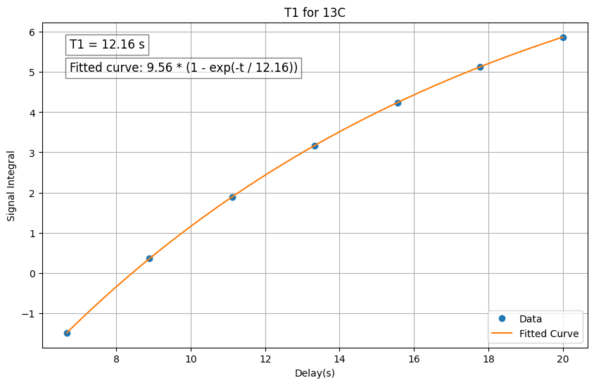

2. $T_1$ with decoupling is 13.72s

   Figure 2. T1 for 13C, with decoupling

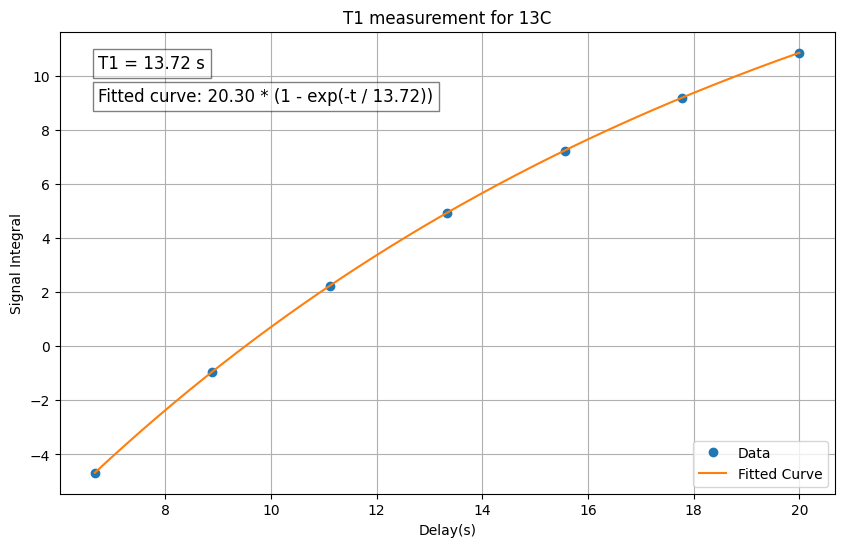

3. Theoretically, the decoupling provide additional relaxation pathway for 13C, which will decrease their $T_1$, however, we observed the opposite. One possible explaination is that we conducted these two experiment on a different day, some factor that we did not observe changed.

## Experiment 7: CPMG experiment

### Intuition:

1. The pulse sequence below does this: constantly doing echo to correct error caused by static field inhomogeneities. The receiver collects data while transmitter waits

### Pulse sequence:

initpp(dir) # Reset internal parameter list

```
  pulse(1,a90,p1,dPulse)                   # 90 RF pulse
  delay(d90_180)                           # 90 - 180 delay
  loop("l1",nEchoes)
     pulse(1,a180,p2,dPulse)               # 180 RF pulse
     delay(d180_acq)                       # 180 - acq delay
     acquire("append",nPnts,dAcq_180)   # Integrate the acquire echo and wait
  endloop("l1")
```

lst = endpp() # Return parameter list

### Parameters:

[output not shown]

### Observation

1. Figure 1 is the Time domain signal for this CPMG experiment, the T2 is 2.37s

   Figure 1. T2 measurement for 13C using CPMG

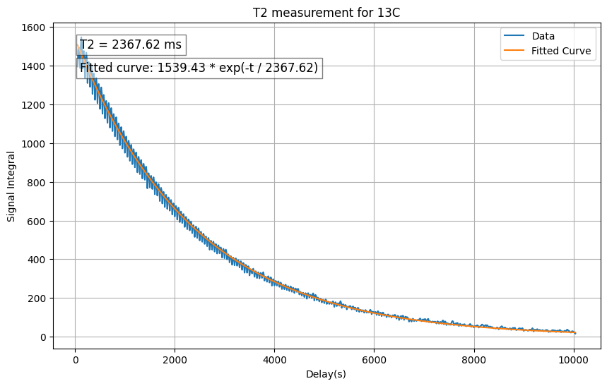

2. The CPMG repeatedly apply $\pi$ pulse on the qubit, removing the effects of static inhomogeneities. Allowing direct measurement on $T_2$. The sequence does not change the intrinsic decoherence mechanisms at high frequencies, however, it suppresses certain low-frequency noise components, therefore it the $T_2$ should be longer.